# Histograms

David Gerbing

## Data

Most of the following examples are an analysis of data in the *Employee* data set, included with **lessR**. First read the *Employee* data into the data frame *d*. See the `Read and Write` vignette for more details.

```r
d <- Read("Employee")
```

```
##
## >>> Suggestions
## Recommended binary format for data files: feather
##   Create with Write(d, "your_file", format="feather")
## More details about your data, Enter:  details()  for d, or  details(name)
##
## Data Types
## ------------------------------------------------------------
## character: Non-numeric data values
## integer: Numeric data values, integers only
## double: Numeric data values with decimal digits
## ------------------------------------------------------------
##
##     Variable                  Missing  Unique
##         Name     Type  Values  Values  Values   First and last values
## ------------------------------------------------------------------------------------------
##  1     Years   integer     36       1      16   7  NA  7 ... 1  2  10
##  2    Gender character     37       0       2   M  M  W ... W  W  M
##  3      Dept character     36       1       5   ADMN  SALE  FINC ... MKTG  SALE  FINC
##  4    Salary    double     37       0      37   53788.26  94494.58 ... 56508.32  57562.36
##  5    JobSat character     35       2       3   med  low  high ... high  low  high
##  6      Plan   integer     37       0       3   1  1  2 ... 2  2  1
##  7       Pre   integer     37       0      27   82  62  90 ... 83  59  80
##  8      Post   integer     37       0      22   92  74  86 ... 90  71  87
## ------------------------------------------------------------------------------------------
```

As an option, also read the table of variable labels. Create the table formatted as two columns. The first column is the variable name and the second column is the corresponding variable label. Not all variables need be entered into the table. The table can be a `csv` file or an Excel file.

Read the label file into the *l* data frame, currently the only permitted name. The labels will be displayed on both the text and visualization output. Each displayed label is the variable name juxtaposed with the corresponding label, as shown in the following output.

```r
l <- rd("Employee_lbl")
```

```
##
## >>> Suggestions
## Recommended binary format for data files: feather
##   Create with Write(d, "your_file", format="feather")
## More details about your data, Enter:  details()  for d, or  details(name)
##
## Data Types
## ------------------------------------------------------------
## character: Non-numeric data values
## ------------------------------------------------------------
##
##     Variable                  Missing  Unique
##         Name     Type  Values  Values  Values   First and last values
## ------------------------------------------------------------------------------------------
##  1     label character      8       0       8   Time of Company Employment ... Test score on legal issues after instruction
## ------------------------------------------------------------------------------------------
```

```r
l
```

```
##                                                label
## Years                     Time of Company Employment
## Gender                                  Man or Woman
## Dept                             Department Employed
## Salary                           Annual Salary (USD)
## JobSat            Satisfaction with Work Environment
## Plan             1=GoodHealth, 2=GetWell, 3=BestCare
## Pre    Test score on legal issues before instruction
## Post    Test score on legal issues after instruction
```

## Histogram

One of the most frequently encountered visualizations for continuous variables is the histogram, which outlines the general shape of the underlying distribution.

> *Histogram*: Bin similar values into a group, then plot the frequency of occurrence of the data values in each bin proportional to the height of the corresponding bar.

A call to a function to create a histogram contains the name of the continuous variable that contains the plotted values. With the `Histogram()` function, that variable name is the first parameter value passed to the function. In this example, the *only* parameter value passed to the function is the variable name. The data frame is named *d*, the default value. The following illustrates the call to `Histogram()` with a continuous variable named $x$.

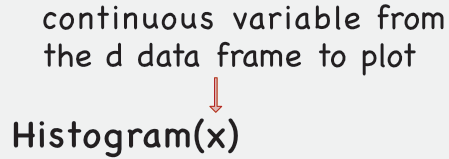

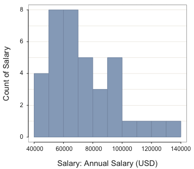

Histogram of tablulated counts for the bins of Salary.

```
## >>> Suggestions
## bin_width: set the width of each bin
## bin_start: set the start of the first bin
## bin_end: set the end of the last bin
## Histogram(Salary, density=TRUE)  # smoothed curve + histogram
## Plot(Salary)  # Violin/Box/Scatterplot (VBS) plot
##
## --- Salary ---
##
##      n   miss         mean           sd          min          mdn          max
##      37      0    73795.557    21799.533    46124.970    69547.600   134419.230
##
##
## --- Outliers ---     from the box plot: 1
##
## Small      Large
## -----      -----
##             134419.2
##
##
## Bin Width: 10000
## Number of Bins: 10
##
##              Bin  Midpnt  Count    Prop  Cumul.c  Cumul.p
## ---------------------------------------------------------
##   40000 >  50000   45000      4    0.11        4     0.11
##   50000 >  60000   55000      8    0.22       12     0.32
##   60000 >  70000   65000      8    0.22       20     0.54
##   70000 >  80000   75000      5    0.14       25     0.68
##   80000 >  90000   85000      3    0.08       28     0.76
##   90000 > 100000   95000      5    0.14       33     0.89
##  100000 > 110000  105000      1    0.03       34     0.92
##  110000 > 120000  115000      1    0.03       35     0.95
##  120000 > 130000  125000      1    0.03       36     0.97
##  130000 > 140000  135000      1    0.03       37     1.00
```

```r
Histogram(Salary)
```

By default, the `Histogram()` function provides a color theme according to the current, active theme. The function also provides the corresponding frequency distribution, summary statistics, the table that lists the count of each category, from which the histogram is constructed, as well as an outlier analysis based on Tukey’s outlier detection rules for box plots.

## Customize the Histogram

Use the parameters `bin_start`, `bin_width`, and `bin_end` to customize the histogram.

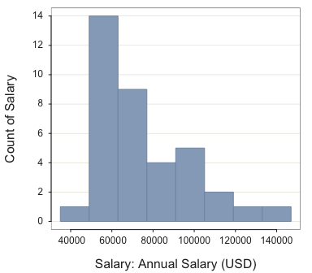

Customized histogram.

```
## >>> Suggestions
## bin_end: set the end of the last bin
## Histogram(Salary, density=TRUE)  # smoothed curve + histogram
## Plot(Salary)  # Violin/Box/Scatterplot (VBS) plot
##
## --- Salary ---
##
##      n   miss         mean           sd          min          mdn          max
##      37      0    73795.557    21799.533    46124.970    69547.600   134419.230
##
##
## --- Outliers ---     from the box plot: 1
##
## Small      Large
## -----      -----
##             134419.2
##
##
## Bin Width: 14000
## Number of Bins: 8
##
##              Bin  Midpnt  Count    Prop  Cumul.c  Cumul.p
## ---------------------------------------------------------
##   35000 >  49000   42000      1    0.03        1     0.03
##   49000 >  63000   56000     14    0.38       15     0.41
##   63000 >  77000   70000      9    0.24       24     0.65
##   77000 >  91000   84000      4    0.11       28     0.76
##   91000 > 105000   98000      5    0.14       33     0.89
##  105000 > 119000  112000      2    0.05       35     0.95
##  119000 > 133000  126000      1    0.03       36     0.97
##  133000 > 147000  140000      1    0.03       37     1.00
```

```r
Histogram(Salary, bin_start=35000, bin_width=14000)
```

Easy to change the color, either by changing the color theme with `style()`, or just change the fill color with `fill`. Can refer to standard R colors, as shown with **lessR** function `showColors()`, or implicitly invoke the **lessR** color palette generating function `getColors()`. Each 30 degrees of the color wheel is named, such as `"greens"`, `"rusts"`, etc, and implements a sequential color palette.

Use the `color` parameter to set the border color, here turned off.

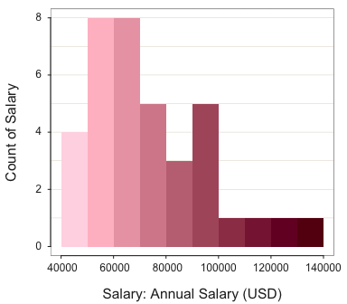

Customized histogram.

```
## >>> Suggestions
## bin_width: set the width of each bin
## bin_start: set the start of the first bin
## bin_end: set the end of the last bin
## Histogram(Salary, density=TRUE)  # smoothed curve + histogram
## Plot(Salary)  # Violin/Box/Scatterplot (VBS) plot
##
## --- Salary ---
##
##      n   miss         mean           sd          min          mdn          max
##      37      0    73795.557    21799.533    46124.970    69547.600   134419.230
##
##
## --- Outliers ---     from the box plot: 1
##
## Small      Large
## -----      -----
##             134419.2
##
##
## Bin Width: 10000
## Number of Bins: 10
##
##              Bin  Midpnt  Count    Prop  Cumul.c  Cumul.p
## ---------------------------------------------------------
##   40000 >  50000   45000      4    0.11        4     0.11
##   50000 >  60000   55000      8    0.22       12     0.32
##   60000 >  70000   65000      8    0.22       20     0.54
##   70000 >  80000   75000      5    0.14       25     0.68
##   80000 >  90000   85000      3    0.08       28     0.76
##   90000 > 100000   95000      5    0.14       33     0.89
##  100000 > 110000  105000      1    0.03       34     0.92
##  110000 > 120000  115000      1    0.03       35     0.95
##  120000 > 130000  125000      1    0.03       36     0.97
##  130000 > 140000  135000      1    0.03       37     1.00
```

```r
Histogram(Salary, fill="reds", color="transparent")
```

## Density Plot

The histogram portrays a continuous distribution with discrete bins, with more modern visualizations available that directly display the estimated underlying smooth curve.

> *Density plot*: A smooth curve that estimates the underlying continuous distribution.

To create a density plot, add the `density` parameter. The result is the filled density curve superimposed on the histogram.

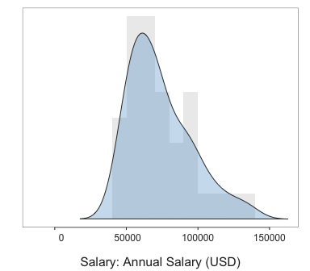

Histogram with density plot.

```
## >>> Suggestions
## bin_width: set the width of each bin
## Histogram(Salary)  # histogram only
## Plot(Salary)  # Violin/Box/Scatterplot (VBS) plot
##
## --- Bandwidth ---      for general curve: 9529.0447
##
##
## --- Salary ---
##
##      n   miss         mean           sd          min          mdn          max
##      37      0    73795.557    21799.533    46124.970    69547.600   134419.230
##
##
## --- Outliers ---     from the box plot: 1
##
## Small      Large
## -----      -----
##             134419.2
```

```r
Histogram(Salary, density=TRUE)
```

The `type` parameter indicates the type of density curve. The default is `"general"`. Options are `"normal"` for a normal density curve and `"both"` for both.

## VBS Plot

A more modern version of the density plot combines the violin plot, box plot, and scatter plot into a single visualization, here called the VBS plot.

```
## [Violin/Box/Scatterplot graphics from Deepayan Sarkar's lattice package]
##
## >>> Suggestions
## Plot(Salary, out_cut=2, fences=TRUE, vbs_mean=TRUE)  # Label two outliers ...
## Plot(Salary, box_adj=TRUE)  # Adjust boxplot whiskers for asymmetry
```

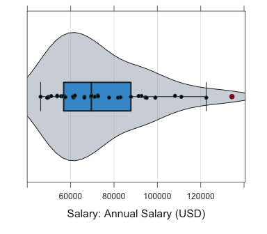

VBS plot.

```
## --- Salary ---
## Present: 37
## Missing: 0
## Total  : 37
##
## Mean         : 73795.557
## Stnd Dev     : 21799.533
## IQR          : 31012.560
## Skew         : 0.190   [medcouple, -1 to 1]
##
## Minimum      : 46124.970
## Lower Whisker: 46124.970
## 1st Quartile : 56772.950
## Median       : 69547.600
## 3rd Quartile : 87785.510
## Upper Whisker: 122563.380
## Maximum      : 134419.230
##
##
## --- Outliers ---     from the box plot: 1
##
## Small      Large
## -----      -----
##             134419.23
##
## Number of duplicated values: 0
##
## Parameter values (can be manually set)
## -------------------------------------------------------
## size: 0.61      size of plotted points
## out_size: 0.82  size of plotted outlier points
## jitter_y: 0.45 random vertical movement of points
## jitter_x: 0.00  random horizontal movement of points
## bw: 9529.04       set bandwidth higher for smoother edges
```

```r
Plot(Salary)
```

## Interactive Histogram

An interactive visualization lets the user in real time change parameter values to change characteristics of the visualization. To create an interactive histogram of the variable *Salary* that displays the corresponding parameters, run the function `interact()` with `"Histogram"` specified.

```
interact("Histogram")
```

The `interact()` function is not run here because interactivity requires to run directly from the R console.

## Full Manual

Use the base R `help()` function to view the full manual for `Histogram()`. Simply enter a question mark followed by the name of the function.

```
?Histogram
```

## More

More on Histograms and other visualizations from **lessR** and other packages such as **ggplot2** at:

Gerbing, D., *R Visualizations: Derive Meaning from Data*, CRC Press, May, 2020, ISBN 978-1138599635.